# Лабораторная работа №11

Управление загрузкой системы

Авраменко Давид Андреевич

1032251973@rudn.ru

Российский университет дружбы народов

2026-11-01

# Цели и задачи работы

## Цель лабораторной работы

Получить практические навыки настройки загрузчика GRUB2, изменения параметров загрузки операционной системы Linux и сохранения изменений в конфигурационном файле.

Изучить способы устранения неполадок загрузки с использованием режимов `rescue.target` и `emergency.target`, а также процедуру восстановления доступа к учётной записи суперпользователя в операционной системе Rocky Linux.

# Процесс выполнения лабораторной работы

## Изменяю параметры загрузчика GRUB2

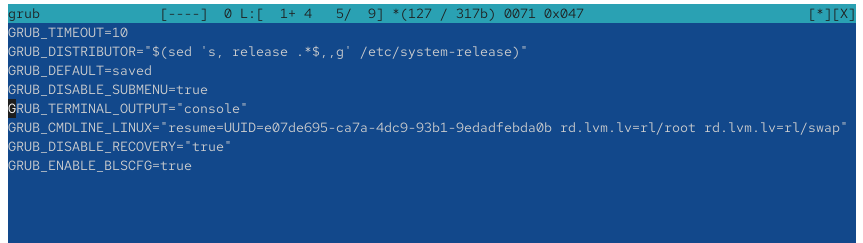

Изменение параметров загрузчика GRUB2

## Формирую новый конфигурационный файл GRUB2

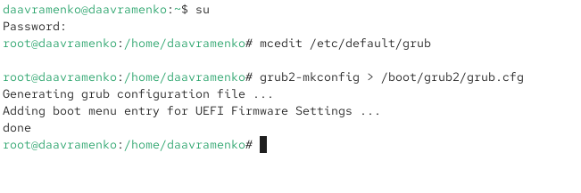

Формирование конфигурационного файла GRUB2

## Проверяю отображение меню загрузчика после изменения конфигурации

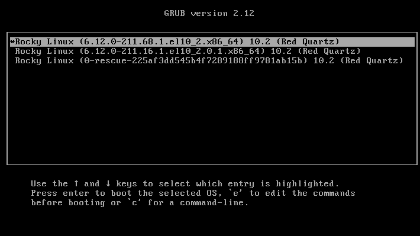

Отображение меню загрузчика GRUB2

## Настраиваю загрузку системы в режиме восстановления rescue.target

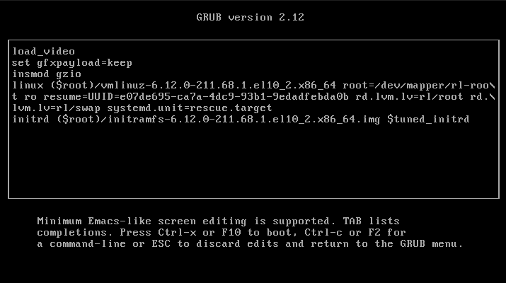

Настройка загрузки в режиме rescue.target

## Просматриваю системные единицы и переменные окружения

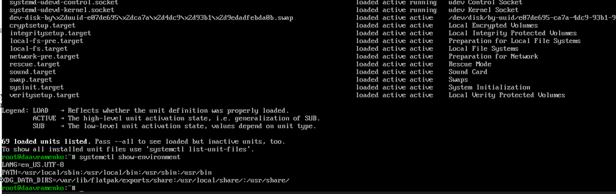

Просмотр загруженных системных единиц и переменных окружения

## Настраиваю загрузку системы в аварийном режиме emergency.target

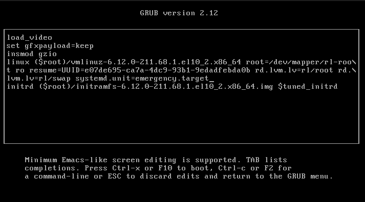

Настройка загрузки в аварийном режиме emergency.target

## Просматриваю системные единицы в аварийном режиме

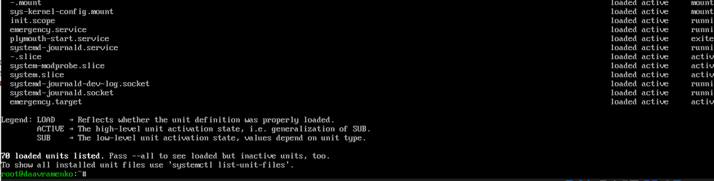

Просмотр системных единиц в аварийном режиме

## Добавляю параметр rd.break для восстановления доступа к системе

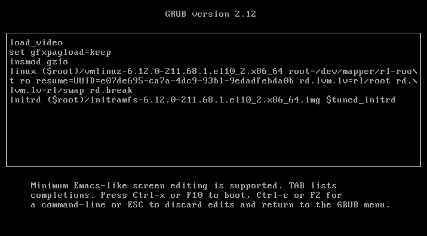

Добавление параметра rd.break для восстановления доступа к системе

## Проверяю возможность сброса пароля суперпользователя

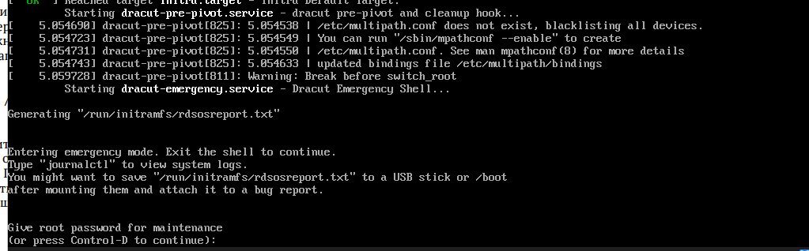

Запрос пароля root при попытке восстановления доступа через rd.break

# Выводы по проделанной работе

## Вывод

В ходе лабораторной работы изучены основные механизмы настройки загрузчика GRUB2 и управления процессом загрузки операционной системы Rocky Linux. Выполнено изменение параметра `GRUB_TIMEOUT` в файле `/etc/default/grub` и обновление конфигурации с помощью команды `grub2-mkconfig`. После перезагрузки проверена работа меню загрузчика.

Изучены режимы восстановления `rescue.target` и `emergency.target`. С помощью команд `systemctl list-units` и `systemctl show-environment` получена информация о загруженных системных единицах и переменных окружения.

Также рассмотрена процедура восстановления пароля пользователя `root` с использованием параметра `rd.break`. После прерывания загрузки система запросила действующий пароль суперпользователя. Поскольку по условию задания пароль забыт, выполнить его сброс по предложенной инструкции не удалось.

В результате получены практические навыки изменения конфигурации GRUB2, редактирования параметров запуска ядра, использования режимов восстановления и диагностики проблем при загрузке операционной системы.